# crabbymetrics

[figure not shown]

crabbymetrics logo

`crabbymetrics` is a Rust-backed econometrics library with a compact Python API. The docs are organized around the public API, a single binding crash course, an active `First Course Ding` translation track, regression/GLM examples, causal-inference examples, transform notes, focused numerical ablations, and a small set of supporting internals pages.

## Start Here

- API reference: verified public surface, summary schemas, optimizer catalog, and runtime smoke checks.
- llms.txt: dense LLM-facing package guide with install notes, data-shape contracts, estimator selection guidance, signatures, examples, source-map pointers, and links.
- First Course Ding: chapter-by-chapter translation plan and current implementation status for the Peng Ding notebooks.
- Binding Crash Course: OLS: the shortest end-to-end walkthrough of the Rust-to-Python wrapper pattern in this codebase.

## First Course Ding

- Overview And TOC: planning page and chapter map for the full Ding translation pass.
- Translated so far: Chapter 1, Chapter 2, Chapter 3, Chapter 4, Chapter 9, Chapter 11, Chapter 12, Chapter 13, Chapter 21, and Chapter 23.
- The next obvious tranche is Chapters 15 through 20, where matching, sensitivity analysis, and RD helpers start to matter.

## Regression And GLM Examples

- OLS: baseline linear regression with switchable vanilla and HC1 covariance estimators.
- Ridge: closed-form L2-regularized least squares with a scalar penalty or a penalty grid plus cross-validation.
- Fixed Effects OLS: partial out one-way or multi-way categorical fixed effects with `within`, then estimate slopes without an intercept.
- ElasticNet: regularized linear regression.
- Logit: binary logistic regression.
- Multinomial Logit: multiclass classification.
- Poisson: count regression, with model-based or QMLE sandwich inference available from `summary(vcov=...)`.
- GMM: fit just-identified score equations, overidentified two-step IV moments, and stacked nuisance-parameter moments with the first-class `GMM` estimator.
- MEstimator Poisson: callback-driven estimation matched against the built-in Poisson estimator.

## Causal Inference Examples

- Balancing Weights: entropy and quadratic calibration weights for ATT-style reweighting, covariate shift, and domain adaptation.
- Cressie-Read And Rényi Balancing: power-divergence balancing weights, Rényi alpha-grid diagnostics, and ATT reweighting under good, medium, and bad overlap.
- EPLM: the Robins-Newey partially linear E-estimator, implemented as a stacked-moment estimator for a scalar continuous treatment.
- Average Derivative: Oaxaca-Blinder, generalized IPW, and doubly robust average-derivative estimators in the Graham-Pinto style under a continuous-treatment working model.
- Double ML And AIPW: cross-fit ridge nuisance estimation for partially linear DML and binary-treatment AIPW.
- Richer Regression With Transformer Pipelines: a longer semiparametric-style example built on `KernelBasis` and `PCA`.
- TwoSLS: instrumental variables regression, including multiple endogenous regressors and multiple excluded instruments.
- Synthetic Control: simplex-constrained donor weighting for treated-versus-donor panel matching under latent-factor drift.
- Synthetic DID: matrix-panel synthetic difference-in-differences with `fit(Y, W)`.
- Augmented Balancing for Panel Data: combine an externally estimated untreated-outcome surface with unit and time residual balancing in staggered-adoption panels.
- Horizontal Panel Ridge: horizontal-regression counterfactual forecasts for staggered treatment panels.
- Matrix Completion: low-rank completion of treated panel cells under the shared panel matrix contract.
- Interactive Fixed Effects: factor-model decomposition for balanced panels.
- Staggered Panel Event Study: Hainmueller–Hangartner staggered-adoption panel walkthrough comparing crabbymetrics matrix estimators with pyfixest TWFE and saturated event studies.

## Transform Examples

- PCA And Kernel Basis: transformer examples for richer design matrices and nonlinear geometry.

## Ablations

- Variance Estimators: cached Monte Carlo coverage experiments for OLS, Poisson, and GMM variance estimators under heteroskedasticity or overdispersion.
- Semiparametric Estimator Comparisons: cached Monte Carlo comparisons for EPLM versus partially linear DML under continuous-treatment misspecification, and for vanilla regression versus balancing weights versus AIPW under binary treatment.
- Two-Period Semiparametric DID: cached Monte Carlo comparisons for unadjusted, outcome-model, IPW, and AIPW two-period DID under unconditional and conditional parallel trends regimes.
- Bridging Finite And Superpopulation: cached Monte Carlo coverage comparisons for HC2, Ding’s closed-form correction, a raw-row bootstrap, and stacked GMM when the same adjusted estimator is evaluated against SATE and PATE.
- Panel Estimator DGP Comparisons: cached Monte Carlo ATT comparisons for TWFE, synthetic control, synthetic DID, and matrix completion across additive, factor, and selected-adoption panel DGPs.
- Randomized Sketching And Least Squares: math notes and cached ablations for randomized QR/SVD sketches, CountSketch OLS, and sketched IV/2SLS on tall designs.
- Same Root Panel Case Studies: cached Basque Country and California Proposition 99 case-study comparisons that put simulation, horizontal/vertical estimators, synthetic DID, matrix completion, and donor-placebo inference in one workflow.

## Optimization

- Optimizers: direct optimizer usage for smooth likelihoods, rougher objective surfaces, and solver behavior comparisons.
- GMM With Optimizers: the lower-level notebook that motivated the first-class `GMM` estimator and still shows the residual-collection view directly.

## Supporting Pages

- Binding Internals: Poisson: a deeper built-in-estimator walkthrough after the OLS crash course.
- Binding Internals: MEstimator: the callback-heavy bridge where Rust owns optimization and Python supplies the objective and scores.

## Runtime Snapshot

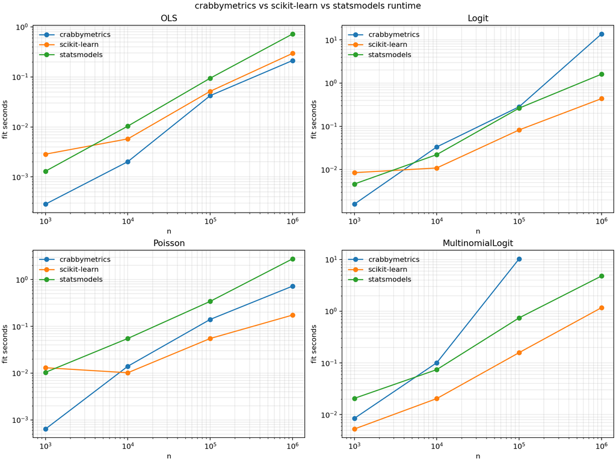

Repo-level runtime comparison for OLS, Logit, Poisson, and MultinomialLogit across `crabbymetrics`, `scikit-learn`, and `statsmodels`. Lower is faster.

The benchmark figure is generated from the repo-level benchmark assets in `benchmarks/` and gives a quick scale check for the estimators that overlap cleanly with mainstream Python baselines.

## Notes

- `api.qmd` remains the main documentation page and renders to `api.html`.
- The site is a Quarto website, so shared navigation and search are generated under `docs/`.
- All pages are rendered with embedded resources so the checked-in HTML files remain self-contained.